# 06_Spatial_Regridding_and_Masking_Fire_example

## 06 - Spatial Regridding and masking data cubes

### A DeepESDL example notebook

This notebook demonstrates how to access two different data sets, transform one of them so that both share the same spatial grid, and mask one dataset by applying a condition from the other dataset.

Please, also refer to the [DeepESDL documentation](https://deepesdl.readthedocs.io/en/latest/guide/jupyterlab/) and visit the platform's [website](https://www.earthsystemdatalab.net/) for further information!

Brockmann Consult, 2023

**This notebook runs with the python environment `deepesdl-xcube-1.1.2`, please checkout the documentation for [help on changing the environment](https://deepesdl.readthedocs.io/en/latest/guide/jupyterlab/#python-environment-selection-of-the-jupyter-kerne).**

```python
# mandatory imports
from xcube.core.gridmapping import GridMapping
from xcube.core.resampling import resample_in_space
from xcube.core.store import new_data_store
from IPython.display import JSON
import numpy as np
import xarray as xr
import datetime
```

Open CCI store

```python
cci_store = new_data_store('cciodp')
```

Open s3 store and list all datasets

```python
root = "deep-esdl-public"
```

```python
s3_store = new_data_store("s3", root=root)
```

```python
list(s3_store.get_data_ids())
```

```
['LC-1x2160x2160-1.0.0.levels',
 'SMOS-freezethaw-1x720x720-1.0.1.zarr',
 'SMOS-freezethaw-4267x10x10-1.0.1.zarr',
 'black-sea-1x1024x1024.levels',
 'black-sea-256x128x128.zarr',
 'esa-cci-permafrost-1x1151x1641-0.0.2.levels',
 'esdc-8d-0.25deg-1x720x1440-3.0.1.zarr',
 'esdc-8d-0.25deg-256x128x128-3.0.1.zarr',
 'ocean-1M-9km-1x1080x1080-1.4.0.levels',
 'ocean-1M-9km-64x256x256-1.4.0.zarr',
 'polar-100m-1x2048x2048-1.0.1.zarr']
```

Open Land Cover (LC) dataset from s3 bucket, which is saved as a multilevel dataset:

```python
ml_LC = s3_store.open_data('LC-1x2160x2160-1.0.0.levels', decode_cf = True)
```

Lets open level 0, which is the base level and therefor has the highest resolution:

```python
LC = ml_LC.get_dataset(0)
```

```python
LC
```

```
<xarray.Dataset>
Dimensions:              (time: 11, lat: 64800, lon: 129600, bounds: 2)
Coordinates:
  * lat                  (lat) float64 90.0 90.0 89.99 ... -89.99 -90.0 -90.0
  * lon                  (lon) float64 -180.0 -180.0 -180.0 ... 180.0 180.0
  * time                 (time) datetime64[ns] 2010-01-01 ... 2020-01-01
Dimensions without coordinates: bounds
Data variables:
    change_count         (time, lat, lon) uint8 dask.array<chunksize=(1, 2160, 2160), meta=np.ndarray>
    crs                  (time) int32 dask.array<chunksize=(11,), meta=np.ndarray>
    current_pixel_state  (time, lat, lon) float32 dask.array<chunksize=(1, 2160, 2160), meta=np.ndarray>
    lat_bounds           (time, lat, bounds) float64 dask.array<chunksize=(1, 2160, 2), meta=np.ndarray>
    lccs_class           (time, lat, lon) uint8 dask.array<chunksize=(1, 2160, 2160), meta=np.ndarray>
    lon_bounds           (time, lon, bounds) float64 dask.array<chunksize=(1, 2160, 2), meta=np.ndarray>
    observation_count    (time, lat, lon) uint16 dask.array<chunksize=(1, 2160, 2160), meta=np.ndarray>
    processed_flag       (time, lat, lon) float32 dask.array<chunksize=(1, 2160, 2160), meta=np.ndarray>
    time_bounds          (time, bounds) datetime64[ns] dask.array<chunksize=(1, 2), meta=np.ndarray>
Attributes: (12/38)
    Conventions:                CF-1.6
    TileSize:                   2025:2025
    cdm_data_type:              grid
    comment:
    contact:                    https://www.ecmwf.int/en/about/contact-us/get...
    creation_date:              20181130T095431Z
    ...                         ...
    time_coverage_end:          20101231
    time_coverage_resolution:   P1Y
    time_coverage_start:        20100101
    title:                      Land Cover Map of ESA CCI brokered by CDS
    tracking_id:                96ac9aca-1ca7-45c6-b4a5-ab448c692646
    type:                       ESACCI-LC-L4-LCCS-Map-300m-P1Y
```

Now let's search for fire datasets provided via the xcube cci store:

```python
iterator = cci_store.search_data(cci_attrs=dict(ecv='FIRE'))
JSON([item.to_dict() for item in iterator])
```

Open Fire dataset from xcube cci store:

```python
fire = cci_store.open_data('esacci.FIRE.mon.L4.BA.MODIS.Terra.MODIS_TERRA.v5-1.grid')
fire
```

```
<xarray.Dataset>
Dimensions:                          (time: 240, lat: 720, lon: 1440,
                                      vegetation_class: 18, nv: 2, bnds: 2)
Coordinates:
  * lat                              (lat) float32 89.88 89.62 ... -89.62 -89.88
    lat_bnds                         (lat, nv) float32 dask.array<chunksize=(720, 2), meta=np.ndarray>
  * lon                              (lon) float32 -179.9 -179.6 ... 179.6 179.9
    lon_bnds                         (lon, nv) float32 dask.array<chunksize=(1440, 2), meta=np.ndarray>
  * time                             (time) datetime64[ns] 2001-01-16T12:00:0...
    time_bnds                        (time, bnds) datetime64[ns] dask.array<chunksize=(240, 2), meta=np.ndarray>
  * vegetation_class                 (vegetation_class) int32 10 20 ... 170 180
Dimensions without coordinates: nv, bnds
Data variables:
    burned_area                      (time, lat, lon) float32 dask.array<chunksize=(1, 720, 1440), meta=np.ndarray>
    burned_area_in_vegetation_class  (time, vegetation_class, lat, lon) float32 dask.array<chunksize=(1, 18, 360, 360), meta=np.ndarray>
    fraction_of_burnable_area        (time, lat, lon) float32 dask.array<chunksize=(1, 720, 1440), meta=np.ndarray>
    fraction_of_observed_area        (time, lat, lon) float32 dask.array<chunksize=(1, 720, 1440), meta=np.ndarray>
    number_of_patches                (time, lat, lon) float32 dask.array<chunksize=(1, 720, 1440), meta=np.ndarray>
    standard_error                   (time, lat, lon) float32 dask.array<chunksize=(1, 720, 1440), meta=np.ndarray>
Attributes:
    Conventions:             CF-1.7
    title:                   esacci.FIRE.mon.L4.BA.MODIS.Terra.MODIS_TERRA.v5...
    date_created:            2023-08-30T14:33:39.046347
    processing_level:        L4
    time_coverage_start:     2001-01-01T00:00:00
    time_coverage_end:       2021-01-01T00:00:00
    time_coverage_duration:  P7305DT0H0M0S
    history:                 [{'program': 'xcube_cci.chunkstore.CciChunkStore...
```

**Subsetting time and space for the sake of an efficient example**

Temporal subset, entire 2020:

```python
start_date = datetime.datetime(2020,1,1)
stop_date = datetime.datetime(2020,12,31)
```

Spatial subset, southern/central Europe:

```python
min_lat = 52.5
max_lat = 36.9
min_lon = -10.
max_lon = 22.9
```

Subsetting the Land Cover dataset, results in only one time slice per year for LC:

```python
LC = LC.sel(lat=slice(min_lat, max_lat),
            lon=slice(min_lon, max_lon),
            time=slice(start_date, stop_date))
```

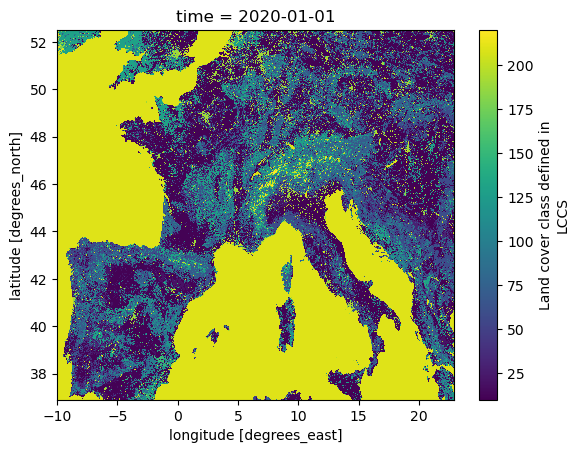

```python
LC.lccs_class.isel(time=0).plot.imshow()
```

```python
LC
```

```
<xarray.Dataset>
Dimensions:              (time: 1, lat: 5616, lon: 11844, bounds: 2)
Coordinates:
  * lat                  (lat) float64 52.5 52.5 52.49 52.49 ... 36.91 36.9 36.9
  * lon                  (lon) float64 -9.999 -9.996 -9.993 ... 22.89 22.9 22.9
  * time                 (time) datetime64[ns] 2020-01-01
Dimensions without coordinates: bounds
Data variables:
    change_count         (time, lat, lon) uint8 dask.array<chunksize=(1, 1620, 1440), meta=np.ndarray>
    crs                  (time) int32 dask.array<chunksize=(1,), meta=np.ndarray>
    current_pixel_state  (time, lat, lon) float32 dask.array<chunksize=(1, 1620, 1440), meta=np.ndarray>
    lat_bounds           (time, lat, bounds) float64 dask.array<chunksize=(1, 1620, 2), meta=np.ndarray>
    lccs_class           (time, lat, lon) uint8 dask.array<chunksize=(1, 1620, 1440), meta=np.ndarray>
    lon_bounds           (time, lon, bounds) float64 dask.array<chunksize=(1, 1440, 2), meta=np.ndarray>
    observation_count    (time, lat, lon) uint16 dask.array<chunksize=(1, 1620, 1440), meta=np.ndarray>
    processed_flag       (time, lat, lon) float32 dask.array<chunksize=(1, 1620, 1440), meta=np.ndarray>
    time_bounds          (time, bounds) datetime64[ns] dask.array<chunksize=(1, 2), meta=np.ndarray>
Attributes: (12/38)
    Conventions:                CF-1.6
    TileSize:                   2025:2025
    cdm_data_type:              grid
    comment:
    contact:                    https://www.ecmwf.int/en/about/contact-us/get...
    creation_date:              20181130T095431Z
    ...                         ...
    time_coverage_end:          20101231
    time_coverage_resolution:   P1Y
    time_coverage_start:        20100101
    title:                      Land Cover Map of ESA CCI brokered by CDS
    tracking_id:                96ac9aca-1ca7-45c6-b4a5-ab448c692646
    type:                       ESACCI-LC-L4-LCCS-Map-300m-P1Y
```

Subsetting the Fire dataset:

```python
fire = fire.sel(lat=slice(min_lat, max_lat),
                lon=slice(min_lon, max_lon),
                time=slice(start_date, stop_date))
```

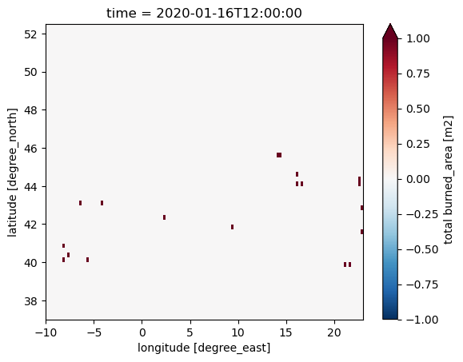

```python
fire.burned_area.isel(time=0).plot.imshow(vmin=-1)
```

**Resample to the same Grid**

Here we use xcube's GridMapping method to extract the specification of both grids. Fire is the grid to be transformed.

```python
source_gm = GridMapping.from_dataset(fire)
```

```python
source_gm
```

class: **RegularGridMapping**

- is_regular: True

- is_j_axis_up: False

- is_lon_360: False

- crs: EPSG:4326

- xy_res: (0.25, 0.25)

- xy_bbox: (-10, 37, 23, 52.5)

- ij_bbox: (0, 0, 132, 62)

- xy_dim_names: ('lon', 'lat')

- xy_var_names: ('lon', 'lat')

- size: (132, 62)

- tile_size: (132, 62)

The target grid mapping is the one from the Land Cover dataset:

```python
target_gm = GridMapping.from_dataset(LC)
```

```python
target_gm
```

class: **RegularGridMapping**

- is_regular: True

- is_j_axis_up: False

- is_lon_360: False

- crs: EPSG:4326

- xy_res: (0.002777775, 0.002777775)

- xy_bbox: (-10, 36.90000000138889, 22.899999998611108, 52.4999999986111)

- ij_bbox: (0, 0, 11844, 5616)

- xy_dim_names: ('lon', 'lat')

- xy_var_names: ('lon', 'lat')

- size: (11844, 5616)

- tile_size: (2160, 2160)

Now we resample Fire to the grid provided by Land Cover:

```python
resampled_fire = resample_in_space(fire,
                                   source_gm=source_gm,
                                   target_gm=target_gm)
```

Lets compare the different grid mappings, to see whether the resampeled fire datasets has the desired grid mapping now:

Our source gridmapping, the original fire grid mapping:

```python
source_gm.crs
```

```
<Geographic 2D CRS: EPSG:4326>
Name: WGS 84
Axis Info [ellipsoidal]:
- Lat[north]: Geodetic latitude (degree)
- Lon[east]: Geodetic longitude (degree)
Area of Use:
- name: World.
- bounds: (-180.0, -90.0, 180.0, 90.0)
Datum: World Geodetic System 1984 ensemble
- Ellipsoid: WGS 84
- Prime Meridian: Greenwich
```

The grid mapping of Land Cover which was the target grid mapping:

```python
target_gm.crs
```

```
<Geographic 2D CRS: EPSG:4326>
Name: WGS 84
Axis Info [ellipsoidal]:
- Lat[north]: Geodetic latitude (degree)
- Lon[east]: Geodetic longitude (degree)
Area of Use:
- name: World.
- bounds: (-180.0, -90.0, 180.0, 90.0)
Datum: World Geodetic System 1984 ensemble
- Ellipsoid: WGS 84
- Prime Meridian: Greenwich
```

The grid mapping of our resampeled Fire, which is as expeced the same as the target grid mapping.

```python
GridMapping.from_dataset(resampled_fire).crs
```

```
<Geographic 2D CRS: EPSG:4326>
Name: WGS 84
Axis Info [ellipsoidal]:
- Lat[north]: Geodetic latitude (degree)
- Lon[east]: Geodetic longitude (degree)
Area of Use:
- name: World.
- bounds: (-180.0, -90.0, 180.0, 90.0)
Datum: World Geodetic System 1984 ensemble
- Ellipsoid: WGS 84
- Prime Meridian: Greenwich
```

**Create a mask from LC classes**

Now that we have our two datasets with the same gridmapping we can use the land cover classes to mask the Fire dataset.

```python
LC.lccs_class.attrs['flag_values'] = np.array(LC.lccs_class.attrs['flag_values'])
```

Extracting only categories, which concern trees:

```python
tree_categories = [[LC.lccs_class.attrs['flag_values'][i],j] for i,j in enumerate(LC.lccs_class.attrs["flag_meanings"].split(" ")) if "tree" in j]
```

```python
tree_categories
```

```
[[12, 'cropland_rainfed_tree_or_shrub_cover'],
 [50, 'tree_broadleaved_evergreen_closed_to_open'],
 [60, 'tree_broadleaved_deciduous_closed_to_open'],
 [61, 'tree_broadleaved_deciduous_closed'],
 [62, 'tree_broadleaved_deciduous_open'],
 [70, 'tree_needleleaved_evergreen_closed_to_open'],
 [71, 'tree_needleleaved_evergreen_closed'],
 [72, 'tree_needleleaved_evergreen_open'],
 [80, 'tree_needleleaved_deciduous_closed_to_open'],
 [81, 'tree_needleleaved_deciduous_closed'],
 [82, 'tree_needleleaved_deciduous_open'],
 [90, 'tree_mixed'],
 [100, 'mosaic_tree_and_shrub'],
 [151, 'sparse_tree'],
 [160, 'tree_cover_flooded_fresh_or_brakish_water'],
 [170, 'tree_cover_flooded_saline_water']]
```

```python
LC_tree_mask = LC.lccs_class.isin([e[0] for e in tree_categories]).compute()
```

Although the coordiantes of the LC dataset and the resampled_fire dataset are almost identical, tiny numerical differences would prevent the masking from working. Thus, the coordinates from the resampled_fire dataset are assigned as the coordinates to the LC_tree_mask

```python
LC_tree_mask = LC_tree_mask.assign_coords(lat = resampled_fire.lat,
                                          lon = resampled_fire.lon).compute()
```

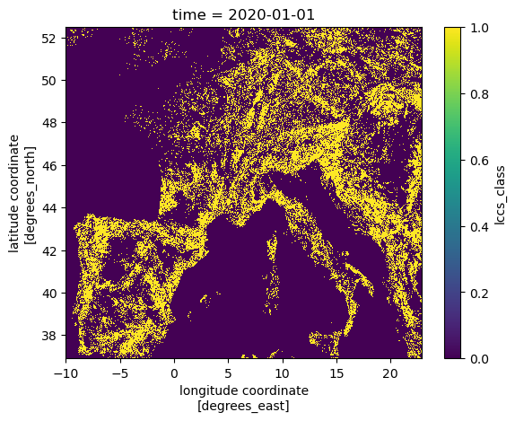

```python
LC_tree_mask.plot()
```

**For the masking to work, both data arrays must have identical coordinates, we thus enforce this condition by assigning coordinates and merging into one dataset**

Because both dasets share the same spatial grid, we can mask the burned_area variable of the fire dataset with the LC_tree_mask and create a new data variable into the resampled_fire datacube. By selecting the only time slice, we remove the time information here.

```python
resampled_fire['burned_tree_area'] = resampled_fire.burned_area.where(LC_tree_mask.isel(time=0))
```

```python
resampled_fire
```

```
<xarray.Dataset>
Dimensions:                          (time: 12, lat: 5616, lon: 11844,
                                      vegetation_class: 18, bnds: 2)
Coordinates:
  * time                             (time) datetime64[ns] 2020-01-16T12:00:0...
  * vegetation_class                 (vegetation_class) int32 10 20 ... 170 180
    time_bnds                        (time, bnds) datetime64[ns] dask.array<chunksize=(12, 2), meta=np.ndarray>
  * lon                              (lon) float64 -9.999 -9.996 ... 22.9 22.9
  * lat                              (lat) float64 52.5 52.5 52.49 ... 36.9 36.9
    lon_bnds                         (lon, bnds) float64 -10.0 -9.997 ... 22.9
    lat_bnds                         (lat, bnds) float64 52.5 52.5 ... 36.9 36.9
Dimensions without coordinates: bnds
Data variables:
    burned_area                      (time, lat, lon) float32 dask.array<chunksize=(1, 2160, 2160), meta=np.ndarray>
    burned_area_in_vegetation_class  (time, vegetation_class, lat, lon) float32 dask.array<chunksize=(1, 1, 2160, 2160), meta=np.ndarray>
    fraction_of_burnable_area        (time, lat, lon) float32 dask.array<chunksize=(1, 2160, 2160), meta=np.ndarray>
    fraction_of_observed_area        (time, lat, lon) float32 dask.array<chunksize=(1, 2160, 2160), meta=np.ndarray>
    number_of_patches                (time, lat, lon) float32 dask.array<chunksize=(1, 2160, 2160), meta=np.ndarray>
    standard_error                   (time, lat, lon) float32 dask.array<chunksize=(1, 2160, 2160), meta=np.ndarray>
    burned_tree_area                 (time, lat, lon) float32 dask.array<chunksize=(1, 2160, 2160), meta=np.ndarray>
Attributes:
    Conventions:             CF-1.7
    title:                   esacci.FIRE.mon.L4.BA.MODIS.Terra.MODIS_TERRA.v5...
    date_created:            2023-08-30T14:33:39.046347
    processing_level:        L4
    time_coverage_start:     2001-01-01T00:00:00
    time_coverage_end:       2021-01-01T00:00:00
    time_coverage_duration:  P7305DT0H0M0S
    history:                 [{'program': 'xcube_cci.chunkstore.CciChunkStore...
```

Plot the burned area of the fire dataset for the first time stamp.

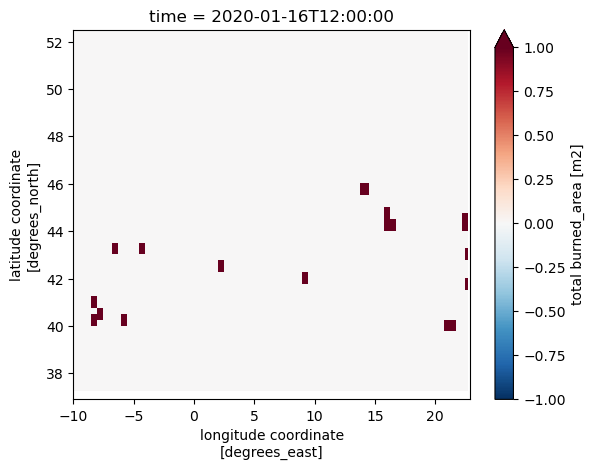

```python
resampled_fire.burned_area.isel(time=0).plot.imshow(vmin=-1)
```

Now lets plot the burned area with the Landcover information. Note, that burned area which is 0 but within the tree category will show up with the value 0 in the plot:

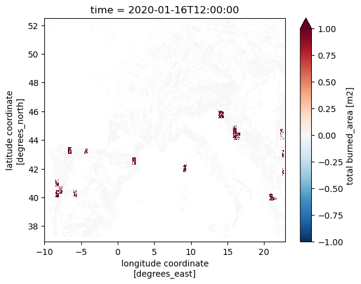

```python
resampled_fire.burned_tree_area.isel(time=0).plot.imshow(vmin=-1)
```

Lets save the resampled fire datacube locally, so we can visualize it faster.

```python
resampled_fire.to_zarr("resampled_fire.zarr")
```

```
<xarray.backends.zarr.ZarrStore at 0x7fe679a06260>
```

```python
from xcube.webapi.viewer import Viewer
```

```python
resampled_fire = xr.open_zarr("resampled_fire.zarr")
```

```python
viewer = Viewer()
```

```python
viewer.add_dataset(resampled_fire)
```

```
'1d292bff-4857-455d-bb10-059ebea6843e'
```

```python
viewer.info()
```

```
Server: https://deep.earthsystemdatalab.net/user/alicebalfanz/proxy/8003
Viewer: https://deep.earthsystemdatalab.net/user/alicebalfanz/proxy/8003/viewer/?serverUrl=https://deep.earthsystemdatalab.net/user/alicebalfanz/proxy/8003
```

```python
viewer.show()
```

[interactive chart not shown]

[output not shown]